# Practica02

Christian Meza, Carlos Alama y Rony Orocollo

2024-05-17

# Actividad Evaluable 2

## 1. Datos Elegantes + Análisis de Datos con Web Scrapping

### Pregunta 1:

Queremos programar un programa de tipo web scrapping con el que podamos obtener una página web, mediante su URL, y poder analizar su contenido HTML con tal de extraer datos e información específica.

#### 1.1. Descargar la página web de la URL indicada, y almacenarlo en un formato de “R” apto para ser tratado.

Instalaciòn de las librerìas

```r
#install.packages("httr")
#install.packages("XML")
#install.packages("ggplot")
library(ggplot2)
library(httr)
library(XML)
```

URL de la página web a descargar

```r
url <- "https://www.mediawiki.org/wiki/MediaWiki.com"
respuesta <- GET(url)
dominio <- "https://www.mediawiki.org"

# Obtener el contenido de la respuesta como texto
contenido_html <- content(respuesta, as = "text", encoding = "UTF-8")
contenido_xml <- htmlTreeParse(contenido_html, useInternalNodes = TRUE)
```

##### 1.2. Analizar el contenido de la web, buscando el título de la página (que en HTML se etiqueta como “title”).

```r
# Extraer el título de la página
titulo <- xpathSApply(contenido_xml, "//title", xmlValue)
```

El titulo es: MediaWiki.com - MediaWiki.

##### 1.3. Analizar el contenido de la web, buscando todos los enlaces (que en HTML se etiquetan como “a”), buscando el texto del enlace, así como la URL.

```r
# Extraer URL de los enlace <a>
urls_enlaces <- xpathSApply(contenido_xml, "//a", xmlGetAttr, "href")

# Extraer todos los textos de los enlace <href>
texto_enlaces <- xpathSApply(contenido_xml, "//a", xmlValue)

tabla_datos <- data.frame("Enlace" = urls_enlaces,"texto" = texto_enlaces,stringsAsFactors = F)

tabla_datos
```

```
##                                                                                                Enlace
## 1                                                                                        #bodyContent
## 2                                                                                     /wiki/MediaWiki
## 3                                                                                      /wiki/Download
## 4                                                        /wiki/Special:MyLanguage/Category:Extensions
## 5                                                                     https://techblog.wikimedia.org/
## 6                                                          /wiki/Special:MyLanguage/How_to_contribute
## 7                                                              /wiki/Special:MyLanguage/Help:Contents
## 8                                                                 /wiki/Special:MyLanguage/Manual:FAQ
## 9                                                            /wiki/Special:MyLanguage/Manual:Contents
## 10                                                                         /wiki/Project:Support_desk
## 11                                                             /wiki/Special:MyLanguage/Communication
## 12                                                                   https://developer.wikimedia.org/
## 13                                                                       /wiki/Development_statistics
## 14                                                                                 /wiki/Project:Help
```

[output cut: 95 more lines]

##### 1.4. Generar una tabla con cada enlace encontrado, indicando el texto que acompaña el enlace, y el número de veces que aparece un enlace con ese mismo objetivo.

```r
# Contar la frecuencia de cada enlace
  tabla_datos$Frecuencia <- table(tabla_datos$Enlace)[as.character(tabla_datos$Enlace)]

  tabla_datos
```

```
##                                                                                                Enlace
## 1                                                                                        #bodyContent
## 2                                                                                     /wiki/MediaWiki
## 3                                                                                      /wiki/Download
## 4                                                        /wiki/Special:MyLanguage/Category:Extensions
## 5                                                                     https://techblog.wikimedia.org/
## 6                                                          /wiki/Special:MyLanguage/How_to_contribute
## 7                                                              /wiki/Special:MyLanguage/Help:Contents
## 8                                                                 /wiki/Special:MyLanguage/Manual:FAQ
## 9                                                            /wiki/Special:MyLanguage/Manual:Contents
## 10                                                                         /wiki/Project:Support_desk
## 11                                                             /wiki/Special:MyLanguage/Communication
## 12                                                                   https://developer.wikimedia.org/
## 13                                                                       /wiki/Development_statistics
## 14                                                                                 /wiki/Project:Help
```

[output cut: 95 more lines]

##### 1.5. Para cada enlace, seguirlo e indicar si está activo (podemos usar el código de status HTTP al hacer una petición a esa URL).

```r
##convertir url de relativas a absolutas
convertir_url <- function(url){
  if(grepl("^/|^#", url)) {
    url <-paste0("https://www.mediawiki.org", url)
  }
    return(url)
}

## Función para verificar el estado de la URL
verificar_estado <- function(url){
    tryCatch({
      respuesta <- HEAD(url)
      if (status_code(respuesta) == 200) {
        #Sys.sleep(2)
        return("200")
      } else {
        return("nulo")
      }
    }, error = function(e) {
      return("nulo")
    })
  }
tabla_datos$Estado <- lapply(tabla_datos$Enlace, verificar_estado)

tabla_datos
```

```
##                                                                                                Enlace
## 1                                                                                        #bodyContent
## 2                                                                                     /wiki/MediaWiki
## 3                                                                                      /wiki/Download
## 4                                                        /wiki/Special:MyLanguage/Category:Extensions
## 5                                                                     https://techblog.wikimedia.org/
## 6                                                          /wiki/Special:MyLanguage/How_to_contribute
## 7                                                              /wiki/Special:MyLanguage/Help:Contents
## 8                                                                 /wiki/Special:MyLanguage/Manual:FAQ
## 9                                                            /wiki/Special:MyLanguage/Manual:Contents
## 10                                                                         /wiki/Project:Support_desk
## 11                                                             /wiki/Special:MyLanguage/Communication
## 12                                                                   https://developer.wikimedia.org/
## 13                                                                       /wiki/Development_statistics
## 14                                                                                 /wiki/Project:Help
```

[output cut: 95 more lines]

### Pregunta 2:

##### 2.1. Un histograma con la frecuencia de aparición de los enlaces, pero separado por URLs absolutas (con “http…: https:”) y URLs relativas.

```r
# Extraer URL de los enlace <a>
urls_enlaces_1 <- xpathSApply(contenido_xml, "//a", xmlGetAttr, "href")

tabla_datos <- data.frame("Enlace" = urls_enlaces_1)

# Contar la frecuencia de cada enlace
tabla_datos$Frecuencia_ <- table(tabla_datos$Enlace)[as.character(tabla_datos$Enlace)]
tabla_datos
```

```
##                                                                                                Enlace
## 1                                                                                        #bodyContent
## 2                                                                                     /wiki/MediaWiki
## 3                                                                                      /wiki/Download
## 4                                                        /wiki/Special:MyLanguage/Category:Extensions
## 5                                                                     https://techblog.wikimedia.org/
## 6                                                          /wiki/Special:MyLanguage/How_to_contribute
## 7                                                              /wiki/Special:MyLanguage/Help:Contents
## 8                                                                 /wiki/Special:MyLanguage/Manual:FAQ
## 9                                                            /wiki/Special:MyLanguage/Manual:Contents
## 10                                                                         /wiki/Project:Support_desk
## 11                                                             /wiki/Special:MyLanguage/Communication
## 12                                                                   https://developer.wikimedia.org/
## 13                                                                       /wiki/Development_statistics
## 14                                                                                 /wiki/Project:Help
```

[output cut: 95 more lines]

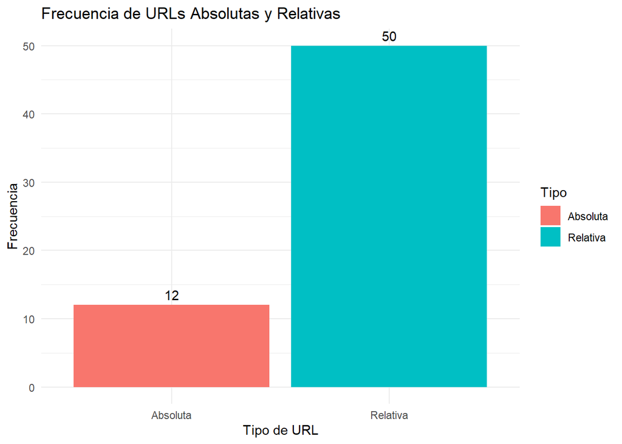

```r
# Clasificar URLs en absolutas y relativas
tabla_datos$Tipo <- ifelse(grepl("^http|^http:", tabla_datos$Enlace), "Absoluta", "Relativa")

# Calcular las frecuencias totales para cada tipo
frecuencias_totales <- aggregate(Frecuencia_ ~ Tipo, data = tabla_datos, sum)

# Crear el histograma usando ggplot2
  ggplot(frecuencias_totales, aes(x = Tipo, y = Frecuencia_, fill = Tipo)) +
  geom_bar(stat = "identity") +
  geom_text(aes(label = Frecuencia_), vjust = -0.5) +  # Añadir etiquetas con las cantidades
  labs(title = "Frecuencia de URLs Absolutas y Relativas", x = "Tipo de URL", y = "Frecuencia") +
  theme_minimal()
```

```r
# Extraer URL de los enlace <a>
urls_enlaces_2 <- xpathSApply(contenido_xml, "//a", xmlGetAttr, "href")

tabla_datos <- data.frame("Enlace" = urls_enlaces_2)

##Detectar url absolutas y relativas dentro del dominio https://www.mediawiki.org
convertir_url <- function(url){
  if(grepl("^/https://www.mediawiki.org|^/http://www.mediawiki.org|^/|^#", url)) {
    return("Dentro del dominio")
  }
    return("Fuera del dominio")
}

tabla_datos$Estatus <- lapply(tabla_datos$Enlace, convertir_url)
tabla_datos
```

```
##                                                                                                Enlace
## 1                                                                                        #bodyContent
## 2                                                                                     /wiki/MediaWiki
## 3                                                                                      /wiki/Download
## 4                                                        /wiki/Special:MyLanguage/Category:Extensions
## 5                                                                     https://techblog.wikimedia.org/
## 6                                                          /wiki/Special:MyLanguage/How_to_contribute
## 7                                                              /wiki/Special:MyLanguage/Help:Contents
## 8                                                                 /wiki/Special:MyLanguage/Manual:FAQ
## 9                                                            /wiki/Special:MyLanguage/Manual:Contents
## 10                                                                         /wiki/Project:Support_desk
## 11                                                             /wiki/Special:MyLanguage/Communication
## 12                                                                   https://developer.wikimedia.org/
## 13                                                                       /wiki/Development_statistics
## 14                                                                                 /wiki/Project:Help
```

[output cut: 95 more lines]

```r
# Contar la cantidad de cada enlace
tabla_datos$Cantidad <- as.integer(table(tabla_datos$Enlace)[as.character(tabla_datos$Enlace)])

# Calcular las frecuencias totales para cada tipo
#Cantidad_totales <- aggregate(Cantidad ~ Estatus, data = tabla_datos, sum)

# Crear el histograma usando ggplot2
#  ggplot(Cantidad_totales, aes(x = Estatus, y = Cantidad, fill = Estatus)) +
#  geom_bar(stat = "identity") +
#  geom_text(aes(label = Cantidad), vjust = -0.5) +  # Añadir etiquetas con las cantidades
#  labs(title = "Frecuencia de URLs Absolutas y Relativas", x = "Estatus", y = "Cantidad") +
#  theme_minimal()
```

##### 2.3. Un gráfico de tarta (pie chart) indicando los porcentajes de Status de nuestro análisis. Por ejemplo, si hay 6 enlaces con status “200” y 4 enlaces con status “404”, la tarta mostrará un 60% con la etiqueta “200” y un 40% con la etiqueta “404”. Este gráfico lo uniremos a los anteriores. El objetivo final es obtener una imagen que recopile los gráficos generados. Usad la capacidad de R y ggplot2 para componer gráficos en una sola figura. Si tales gráficos están compuestos directamente desde R (y no en el documento memoria), se puntuará mejor. Indicar a continuación la solución, justificando cada detalle y decisión tomada, e incluyendo los gráficos.